# QK Box 6.4

Giri et al. (2016) were interested in the capacity of Atlantic salmon (*Salmo salar*), grown in an aquaculture situation, to deliver high levels of omega-3 long-chain polyunsaturated fatty acids (PUFA) in their tissues. Specifically, they tested whether several micronutrients (iron, zinc, magnesium) and coenzymes (riboflavin, biotin and niacin) could increase the conversion from short- to long-chain PUFA. They used four treatments, a diet lacking in these micronutrients and coenzymes (T-0), a diet with normal levels (T-100), and two levels of fortification, where the enzymes and micronutrients were 300% and 600% greater than normal (T-300 and T-600).

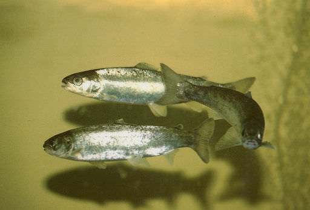

E. Peter Steenstra/USFWS, Public domain, via Wikimedia Commons

Giri, S. S., Graham, J., Hamid, N. K. A., Donald, J. A. & Turchini, G. M. (2016). Dietary micronutrients and in vivo n−3 LC-PUFA biosynthesis in Atlantic salmon. *Aquaculture*, 452, 416-25.

Link to paper; the data are available here

### Preliminaries

First, load the required packages (sjstats, pwr)

Import giri data file (giri.csv)

```r
giri <- read.csv("../data/giri.csv")
head(giri,10)
```

|  | treat | totfa | X12.0 | X14.0 | X15.0 | X16.0 | X17.0 | X18.0 | X20.0 | X22.0 | X14.1n.5 | X16.1n.7 | X18.1n.9 | X18.1n.7 | X20.1n.11 | X20.1n.9 | X22.1n.11 | X22.1n.9 | X24.1n.9 | X18.2n.6 | X18.3n.6 | X20.2n.6 | X20.3n.6 | X20.4n.6 | X22.2n.6 | X22.4n.6 | X22.5n.6 | X18.3n.3 | X18.4n.3 | … |
| --- | --- | --- | --- | --- | --- | --- | --- | --- | --- | --- | --- | --- | --- | --- | --- | --- | --- | --- | --- | --- | --- | --- | --- | --- | --- | --- | --- | --- | --- | --- |
| 1 | 0 | 724.1295 | 0.11311995 | 0.7001967 | 0.09614520 | 10.79261 | 0.3624072 | 4.916537 | 0.04558400 | 0.10311741 | 0.05165660 | 1.493063 | 20.06731 | 1.312220 | 0.07131325 | 0.8956625 | 0.1295140 | 0.1347528 | 0.2494825 | 12.72964 | 0.3102680 | 0.6837724 | 0.5878665 | 0.2478179 | 0 | 0.05182041 | 0.02272989 | 30.61810 | 3.129599 | … |
| 2 | 0 | 772.2095 | 0.06437780 | 0.7639387 | 0.09550004 | 11.15320 | 0.2661609 | 4.856444 | 0.09577035 | 0.10297387 | 0.04313867 | 1.772807 | 21.84741 | 1.305864 | 0.13917788 | 0.7596781 | 0.1180590 | 0.1069015 | 0.1939166 | 12.37986 | 0.3762010 | 0.6372155 | 0.5456440 | 0.2020807 | 0 | 0.08940218 | 0.09310458 | 29.71224 | 3.306681 | … |
| 3 | 0 | 757.6312 | 0.08339414 | 0.7360014 | 0.09692588 | 10.73427 | 0.2977437 | 4.988164 | 0.09192097 | 0.10408159 | 0.05516662 | 1.503177 | 20.32545 | 1.275430 | 0.12501479 | 0.7222478 | 0.1644341 | 0.1089623 | 0.2236961 | 12.89716 | 0.4007868 | 0.5922401 | 0.5492195 | 0.2198609 | 0 | 0.11013317 | 0.10045469 | 30.46555 | 3.727352 | … |
| 4 | 100 | 728.7911 | 0.12158819 | 0.7106978 | 0.12032313 | 10.83691 | 0.3128107 | 4.925921 | 0.04663502 | 0.05369241 | 0.08511323 | 1.546051 | 20.95227 | 1.294497 | 0.10326292 | 1.0042859 | 0.1602915 | 0.1531125 | 0.2831492 | 12.36087 | 0.3744526 | 0.6428516 | 0.5020774 | 0.2944081 | 0 | 0.04693899 | 0.04128009 | 28.62022 | 3.647621 | … |
| 5 | 100 | 717.7978 | 0.10014054 | 0.7062097 | 0.09097234 | 10.93958 | 0.3367226 | 4.969022 | 0.09289405 | 0.10650596 | 0.07044628 | 1.580802 | 21.02940 | 1.279672 | 0.11182744 | 0.8671207 | 0.1068249 | 0.1287644 | 0.2324065 | 12.34897 | 0.4177782 | 0.6531700 | 0.5275558 | 0.2909617 | 0 | 0.09371109 | 0.04094948 | 28.67899 | 3.763489 | … |
| 6 | 100 | 735.4764 | 0.10088928 | 0.7484355 | 0.09893760 | 11.19782 | 0.3526028 | 4.937387 | 0.04673344 | 0.10432422 | 0.04521015 | 1.508021 | 19.60527 | 1.282375 | 0.24092024 | 0.7452420 | 0.2077302 | 0.1249464 | 0.2522699 | 12.31938 | 0.4312701 | 0.5773117 | 0.5284088 | 0.3432670 | 0 | 0.10925671 | 0.15478699 | 28.18541 | 4.091998 | … |
| 7 | 300 | 750.0412 | 0.07897405 | 0.7772819 | 0.10225948 | 10.93941 | 0.3292996 | 4.870330 | 0.09629583 | 0.10332892 | 0.04535100 | 1.564291 | 19.90844 | 1.295770 | 0.20575668 | 0.7525060 | 0.2001073 | 0.1163194 | 0.1878295 | 12.55350 | 0.3749391 | 0.6290713 | 0.5022286 | 0.2930595 | 0 | 0.03651045 | 0.15923434 | 28.90614 | 3.982198 | … |
| 8 | 300 | 753.6881 | 0.08619631 | 0.8336541 | 0.09633609 | 11.41614 | 0.3006235 | 4.871003 | 0.09393678 | 0.10528416 | 0.03821628 | 1.739520 | 21.10360 | 1.318566 | 0.12377896 | 0.8072555 | 0.1758307 | 0.1231278 | 0.2325119 | 12.07887 | 0.3998084 | 0.6382844 | 0.5519742 | 0.2904444 | 0 | 0.08980712 | 0.07840116 | 27.74600 | 3.857569 | … |
| 9 | 300 | 755.6999 | 0.08007046 | 0.7211067 | 0.08974958 | 11.09592 | 0.3174082 | 4.946462 | 0.09030173 | 0.10835383 | 0.07765721 | 1.543292 | 20.29651 | 1.284278 | 0.09860176 | 0.8646810 | 0.1444401 | 0.1164035 | 0.2306289 | 12.25593 | 0.3827816 | 0.6609920 | 0.5139154 | 0.3086401 | 0 | 0.11695744 | 0.09699765 | 28.47716 | 3.540579 | … |
| 10 | 600 | 741.0916 | 0.09598610 | 0.7696898 | 0.09399471 | 11.34867 | 0.3689335 | 5.049470 | 0.09352472 | 0.10758788 | 0.07216821 | 1.631959 | 20.48126 | 1.302260 | 0.23564052 | 0.7714612 | 0.1784384 | 0.1302670 | 0.2321686 | 12.07086 | 0.4029207 | 0.6123663 | 0.5263765 | 0.3307482 | 0 | 0.05581376 | 0.08713426 | 27.97167 | 3.753779 | … |

Make treat a factor

```r
giri$treat <- factor(giri$treat)
```

### Fit model for long-chain omega-3 fatty acids as the response variable

This is the variable n.3.lc.PUFA

```r
giri.aov <- aov(n.3.LC.PUFA~treat, data=giri)
```

Check diagnostics. We are most interested in the residual plot.

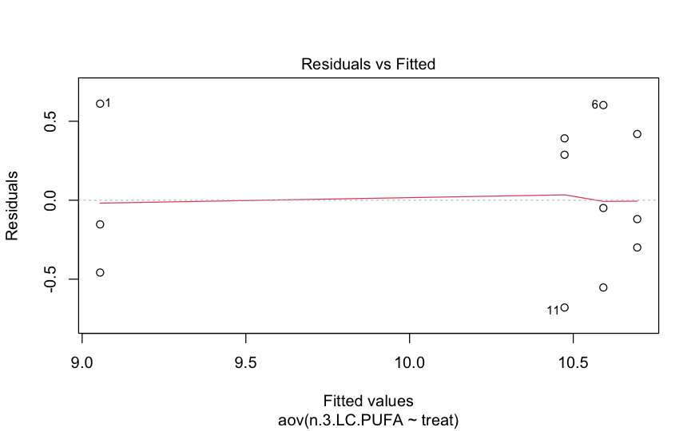

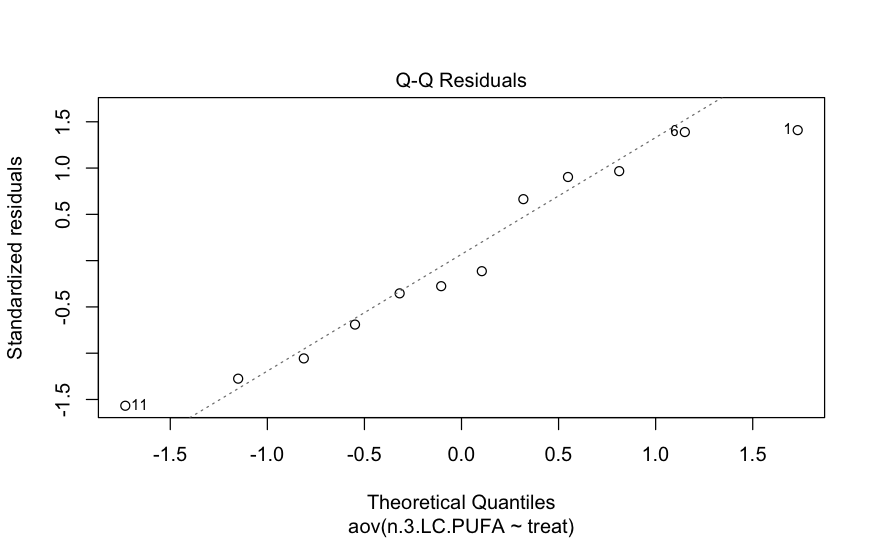

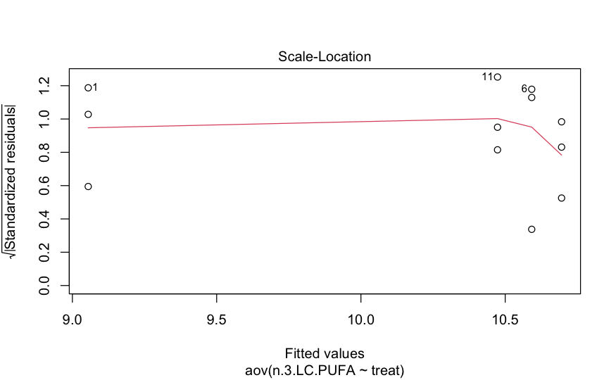

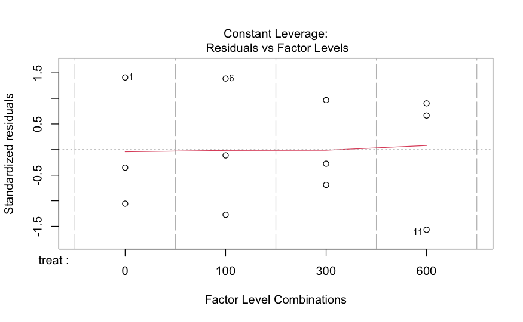

```r
plot(giri.aov)
```

Nothing of concern in diagnostic plots

### Examine model results.

```r
tidy(giri.aov)
```

| term | df | sumsq | meansq | statistic | p.value |
| --- | --- | --- | --- | --- | --- |
| treat | 3 | 5.355145 | 1.7850485 | 6.32974 | 0.01658486 |
| Residuals | 8 | 2.256078 | 0.2820098 | NA | NA |

Get effect sizes

```r
#effectsizes used here to get eta-squared values, which tidy doesn't provide
effectsize(giri.aov)
```

```
For one-way between subjects designs, partial eta squared is equivalent to eta squared. Returning eta squared.
```

```
# Effect Size for ANOVA

Parameter | Eta2 |       95% CI
-------------------------------
treat     | 0.70 | [0.18, 1.00]

- One-sided CIs: upper bound fixed at [1.00].
```

```r
effectsize(giri.aov, type = "omega")
```

```
For one-way between subjects designs, partial omega squared is equivalent to omega squared. Returning omega squared.
```

```
# Effect Size for ANOVA

Parameter | Omega2 |       95% CI
---------------------------------
treat     |   0.57 | [0.00, 1.00]

- One-sided CIs: upper bound fixed at [1.00].
```

```r
effectsize(giri.aov, type = "f")
```

```
For one-way between subjects designs, partial eta squared is equivalent to eta squared. Returning eta squared.
```

```
# Effect Size for ANOVA

Parameter | Cohen's f |      95% CI
-----------------------------------
treat     |      1.54 | [0.48, Inf]

- One-sided CIs: upper bound fixed at [Inf].
```

```r
emmeans(giri.aov, ~treat)
```

```
 treat emmean    SE df lower.CL upper.CL
 0       9.05 0.307  8     8.35     9.76
 100    10.59 0.307  8     9.88    11.30
 300    10.70 0.307  8     9.99    11.40
 600    10.47 0.307  8     9.77    11.18

Confidence level used: 0.95
```

### Do linear polynomial contrast

```r
contrasts(giri$treat) <- contr.poly(4, scores=c(0, 100, 300, 600))
giri1.aov <- aov(n.3.LC.PUFA~treat, data=giri)
summary.aov(giri1.aov, split=list(treat=list("Linear"=1, "Quadratic"=2)))
```

```
                   Df Sum Sq Mean Sq F value Pr(>F)
treat               3  5.355   1.785   6.330 0.0166 *
  treat: Linear     1  1.730   1.730   6.134 0.0383 *
  treat: Quadratic  1  2.496   2.496   8.851 0.0177 *
Residuals           8  2.256   0.282
---
Signif. codes:  0 ‘***’ 0.001 ‘**’ 0.01 ‘*’ 0.05 ‘.’ 0.1 ‘ ’ 1
```